# Analiza skupa podataka o emisijama CO2 registrovanih putničkih vozila

### Prikaz tacnosti modela u zavisnosti od broja iteracija

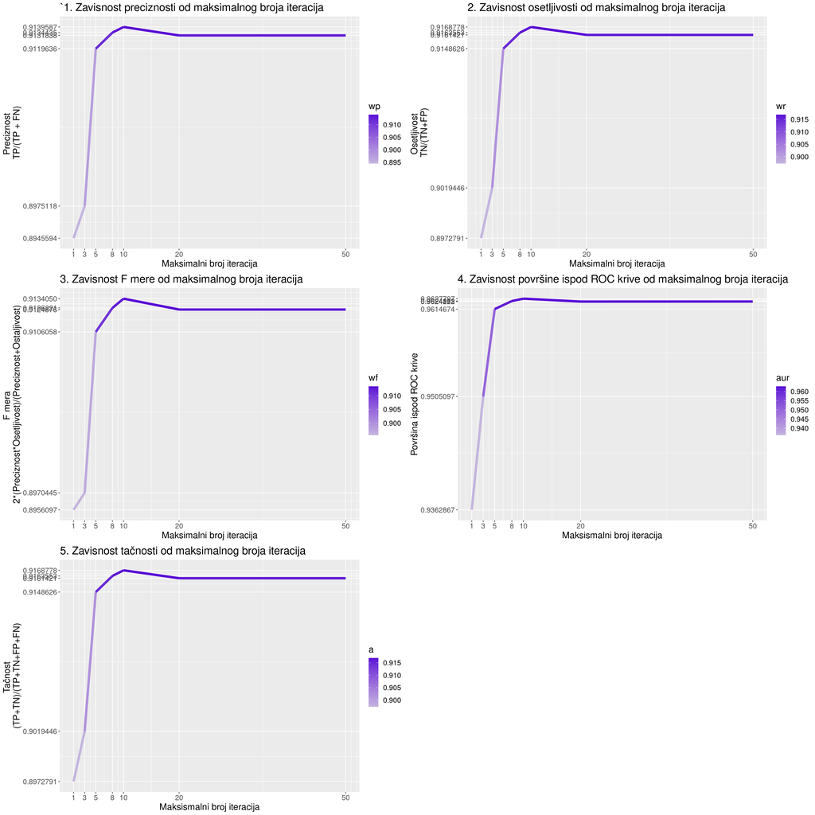

Na grafikonu **1** je predstavljena zavisnost preciznosti od maksimalnog broja iteracija algoritma logističke regresije. Govori nam o tome koliko je model sposoban da prepozna da pojava **priprada** određenoj klasi. Na grafiku možemo da uočimo da preciznost do određenog maksimalnog broja iteracija raste, nakon čega se u neznatnoj meri smanji, a zatim ostaje ista.

Na grafikonu **2** je predstavljena zavisnost osetljivosti od maksimalnog broja iteracija algoritma logističke regresije. Govori nam o tome koliko je model sposoban da prepozna da pojava **ne pripada** određenoj klasi. Ista je situacija kao i kod preciznosti, osetljivost do određeog maksimalnog broja iteracija raste, a u slučaju broja iteracija od 20 ostaje ista.

Na grafikonu **3** je predstavljena zavisnost F mere od maksimalnog broja iteracija algoritma logističke regresije. To je ustvari balans izme]u preciznosti i ostljivosti.

Na grafikonu **4** je prstavljena zavisnost površine ispod ROC (Receiver Operating Characteristic) od maksimalnog broja iteracija algoritma logističke regresije.

## Tačnost različitih klasifikacionih modela u odnosu na metod testiranja modela